# lecture23-caret packages

Sejin Park

```r
library(caret); library(kernlab); data(spam)
inTrain <- createDataPartition(y=spam$type, p=0.75, list=FALSE)
training <- spam[inTrain,]
testing <- spam[-inTrain,]
dim(training)
```

```
## [1] 3451   58
```

## Data splicing

```r
library(caret);library(kernlab);data(spam)
inTrain <- createDataPartition(y=spam$type,
                               p=0.75, list=FALSE)
training <- spam[inTrain,]
testing <- spam[-inTrain,]
dim(training)
```

```
## [1] 3451   58
```

```r
set.seed(32343)
modelFit <- train(type ~. , data=training, method="glm")
modelFit
```

```
## Generalized Linear Model
##
## 3451 samples
##   57 predictors
##    2 classes: 'nonspam', 'spam'
##
## No pre-processing
## Resampling: Bootstrapped (25 reps)
## Summary of sample sizes: 3451, 3451, 3451, 3451, 3451, 3451, ...
## Resampling results
##
##   Accuracy   Kappa      Accuracy SD  Kappa SD
##   0.9129941  0.8172507  0.02478819   0.05163017
##
##
```

```r
modelFit$finalModel
```

```
##
## Call:  NULL
##
## Coefficients:
##       (Intercept)               make            address
##        -1.725e+00         -2.569e-01         -1.359e-01
##               all              num3d                our
##         1.163e-01          2.922e+00          5.130e-01
##              over             remove           internet
##         1.116e+00          2.752e+00          5.288e-01
##             order               mail            receive
##         1.634e+00          5.789e-02         -6.630e-01
##              will             people             report
##        -1.510e-01         -7.160e-02          8.086e-02
##         addresses               free           business
##         1.517e+00          9.233e-01          1.365e+00
##             email                you             credit
##         1.006e-01          6.631e-02          1.236e+00
##              your               font             num000
##         2.796e-01          7.814e-02          2.684e+00
##             money                 hp                hpl
##         2.753e-01         -1.706e+00         -8.448e-01
##            george             num650                lab
##        -2.860e+01          3.627e-01         -2.131e+00
##              labs             telnet             num857
##        -4.063e-01         -6.260e+00          9.211e+00
##              data             num415              num85
##        -7.110e-01          6.900e-01         -1.932e+00
##        technology            num1999              parts
##         7.674e-01         -1.306e-01         -5.615e-01
##                pm             direct                 cs
##        -1.052e+00         -4.878e-01         -4.837e+01
##           meeting           original            project
##        -3.436e+00         -9.557e-01         -1.607e+00
##                re                edu              table
##        -7.372e-01         -1.575e+00         -3.218e+00
##        conference      charSemicolon   charRoundbracket
##        -3.597e+00         -1.116e+00         -2.558e-01
## charSquarebracket    charExclamation         charDollar
##        -8.917e-01          2.058e-01          4.494e+00
##          charHash         capitalAve        capitalLong
##         2.686e+00          1.106e-01          8.423e-03
##      capitalTotal
##         7.868e-04
##
## Degrees of Freedom: 3450 Total (i.e. Null);  3393 Residual
## Null Deviance:       4628
## Residual Deviance: 1273  AIC: 1389
```

## SPAM Example : K-fold

```r
set.seed(32323)
folds <- createFolds(y=spam$type, k=10, list=TRUE, returnTrain=TRUE)
sapply(folds, length)
```

```
## Fold01 Fold02 Fold03 Fold04 Fold05 Fold06 Fold07 Fold08 Fold09 Fold10
##   4141   4140   4141   4142   4140   4142   4141   4141   4140   4141
```

```r
folds[[1]][1:10]
```

```
##  [1]  1  2  3  4  5  6  7  8  9 10
```

## SPAM Example : Return test

```r
set.seed(32323)
folds <- createFolds(y=spam$type, k=10, list=TRUE, returnTrain=FALSE)
sapply(folds, length)
```

```
## Fold01 Fold02 Fold03 Fold04 Fold05 Fold06 Fold07 Fold08 Fold09 Fold10
##    460    461    460    459    461    459    460    460    461    460
```

```r
folds[[1]][1:10]
```

```
##  [1] 24 27 32 40 41 43 55 58 63 68
```

## SPAM Example : Resampling

```r
set.seed(32323)
folds <- createResample(y=spam$type, times=10, list=TRUE)
sapply(folds, length)
```

```
## Resample01 Resample02 Resample03 Resample04 Resample05 Resample06
##       4601       4601       4601       4601       4601       4601
## Resample07 Resample08 Resample09 Resample10
##       4601       4601       4601       4601
```

```r
folds[[1]][1:10]
```

```
##  [1]  1  2  3  3  3  5  5  7  8 12
```

## SPAM Example : Time Slices

```r
set.seed(32323)
tme <- 1:1000
folds <- createTimeSlices(y=tme, initialWindow = 20, horizon=10)
names(folds)
```

```
## [1] "train" "test"
```

## SPAM Example

```r
library(caret);library(kernlab);data(spam)
inTrain <- createDataPartition(y=spam$type,
                               p=0.75, list=FALSE)
training <- spam[inTrain,]
testing <- spam[-inTrain,]
modelFit <- train(type ~. , data=training, method="glm")
```

## Train options

```r
args(train.default)
```

```
## function (x, y, method = "rf", preProcess = NULL, ..., weights = NULL,
##     metric = ifelse(is.factor(y), "Accuracy", "RMSE"), maximize = ifelse(metric ==
##         "RMSE", FALSE, TRUE), trControl = trainControl(), tuneGrid = NULL,
##     tuneLength = 3)
## NULL
```

```r
args(trainControl)
```

```
## function (method = "boot", number = ifelse(grepl("cv", method),
##     10, 25), repeats = ifelse(grepl("cv", method), 1, number),
##     p = 0.75, initialWindow = NULL, horizon = 1, fixedWindow = TRUE,
##     verboseIter = FALSE, returnData = TRUE, returnResamp = "final",
##     savePredictions = FALSE, classProbs = FALSE, summaryFunction = defaultSummary,
##     selectionFunction = "best", preProcOptions = list(thresh = 0.95,
##         ICAcomp = 3, k = 5), sampling = NULL, index = NULL, indexOut = NULL,
##     timingSamps = 0, predictionBounds = rep(FALSE, 2), seeds = NA,
##     adaptive = list(min = 5, alpha = 0.05, method = "gls", complete = TRUE),
##     trim = FALSE, allowParallel = TRUE)
## NULL
```

```r
set.seed(1235)
modelFit2 <- train(type~., data=training, method="glm")
modelFit2
```

```
## Generalized Linear Model
##
## 3451 samples
##   57 predictors
##    2 classes: 'nonspam', 'spam'
##
## No pre-processing
## Resampling: Bootstrapped (25 reps)
## Summary of sample sizes: 3451, 3451, 3451, 3451, 3451, 3451, ...
## Resampling results
##
##   Accuracy   Kappa      Accuracy SD  Kappa SD
##   0.9152739  0.8213541  0.01948848   0.04382679
##
##
```

```r
set.seed(1235)
modelFit3 <- train(type~., data=training, method="glm")
modelFit3
```

```
## Generalized Linear Model
##
## 3451 samples
##   57 predictors
##    2 classes: 'nonspam', 'spam'
##
## No pre-processing
## Resampling: Bootstrapped (25 reps)
## Summary of sample sizes: 3451, 3451, 3451, 3451, 3451, 3451, ...
## Resampling results
##
##   Accuracy   Kappa      Accuracy SD  Kappa SD
##   0.9152739  0.8213541  0.01948848   0.04382679
##
##
```

## Plotting predictor

```r
library(ISLR); library(ggplot2); library(caret);
data(Wage)
summary(Wage)
```

```
##       year           age               sex                    maritl
##  Min.   :2003   Min.   :18.00   1. Male  :3000   1. Never Married: 648
##  1st Qu.:2004   1st Qu.:33.75   2. Female:   0   2. Married      :2074
##  Median :2006   Median :42.00                    3. Widowed      :  19
##  Mean   :2006   Mean   :42.41                    4. Divorced     : 204
##  3rd Qu.:2008   3rd Qu.:51.00                    5. Separated    :  55
##  Max.   :2009   Max.   :80.00
##
##        race                   education                     region
##  1. White:2480   1. < HS Grad      :268   2. Middle Atlantic   :3000
##  2. Black: 293   2. HS Grad        :971   1. New England       :   0
##  3. Asian: 190   3. Some College   :650   3. East North Central:   0
##  4. Other:  37   4. College Grad   :685   4. West North Central:   0
##                  5. Advanced Degree:426   5. South Atlantic    :   0
##                                           6. East South Central:   0
##                                           (Other)              :   0
##            jobclass               health      health_ins      logwage
##  1. Industrial :1544   1. <=Good     : 858   1. Yes:2083   Min.   :3.000
##  2. Information:1456   2. >=Very Good:2142   2. No : 917   1st Qu.:4.447
##                                                            Median :4.653
##                                                            Mean   :4.654
##                                                            3rd Qu.:4.857
##                                                            Max.   :5.763
##
##       wage
##  Min.   : 20.09
##  1st Qu.: 85.38
##  Median :104.92
##  Mean   :111.70
##  3rd Qu.:128.68
##  Max.   :318.34
##
```

```r
inTrain <- createDataPartition(y=Wage$wage, p=0.7, list=FALSE)
training <- Wage[inTrain,]
testing <- Wage[-inTrain,]
dim(training); dim(testing)
```

```
## [1] 2102   12
```

```
## [1] 898  12
```

## Feature plot (caret package)

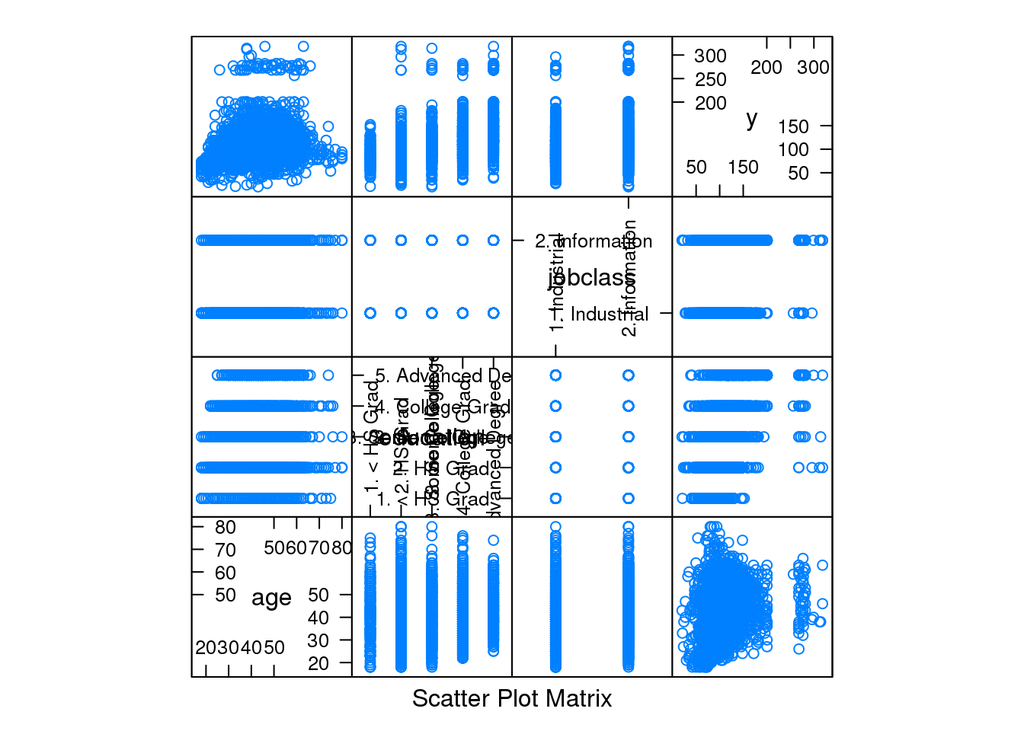

```r
featurePlot(x = training[,c("age", "education", "jobclass")],
            y = training$wage,
            plot="pairs")
```

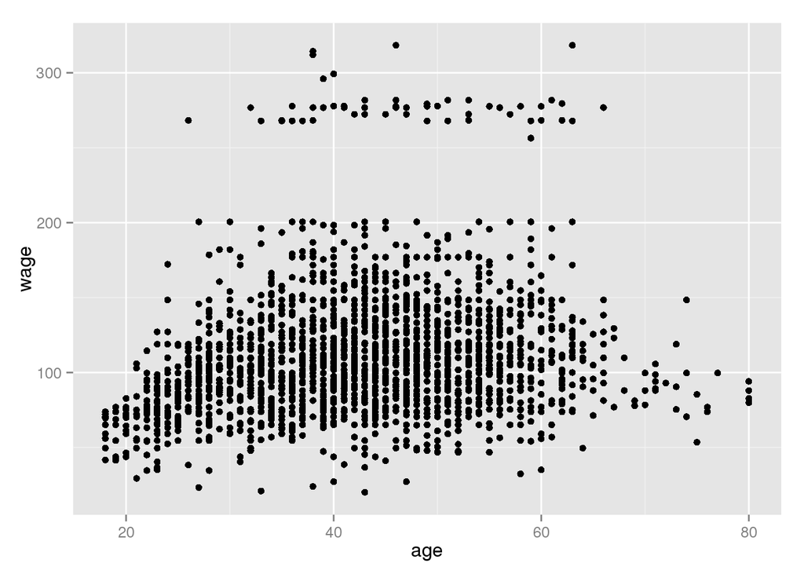

```r
# Qplot (ggplot2 package)
qplot(age, wage, data=training)
```

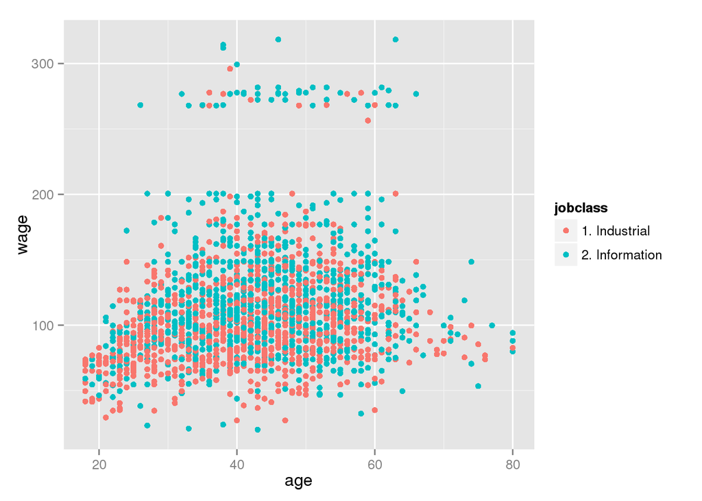

```r
# Qplot with color(ggplot2 package)
qplot(age, wage,color=jobclass, data=training)
```

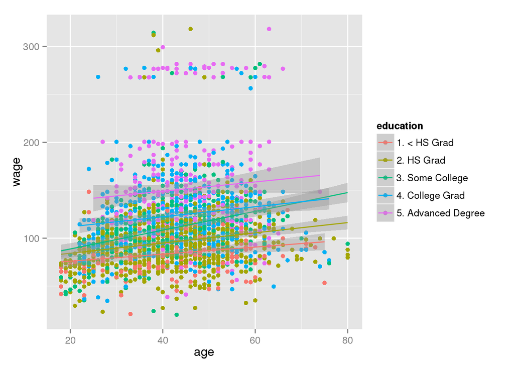

```r
# Add regression smoothers (ggplot2 package)
qq <- qplot(age, wage, colour=education, data=training)
qq + geom_smooth(method="lm", formula=y~x)
```

## cut2, making factors (Hmisc Package)

```r
library("Hmisc")
cutWage <- cut2(training$wage, g=3)
table(cutWage)
```

```
## cutWage
## [ 20.1, 92) [ 92.0,119) [118.9,318]
##         706         733         663
```

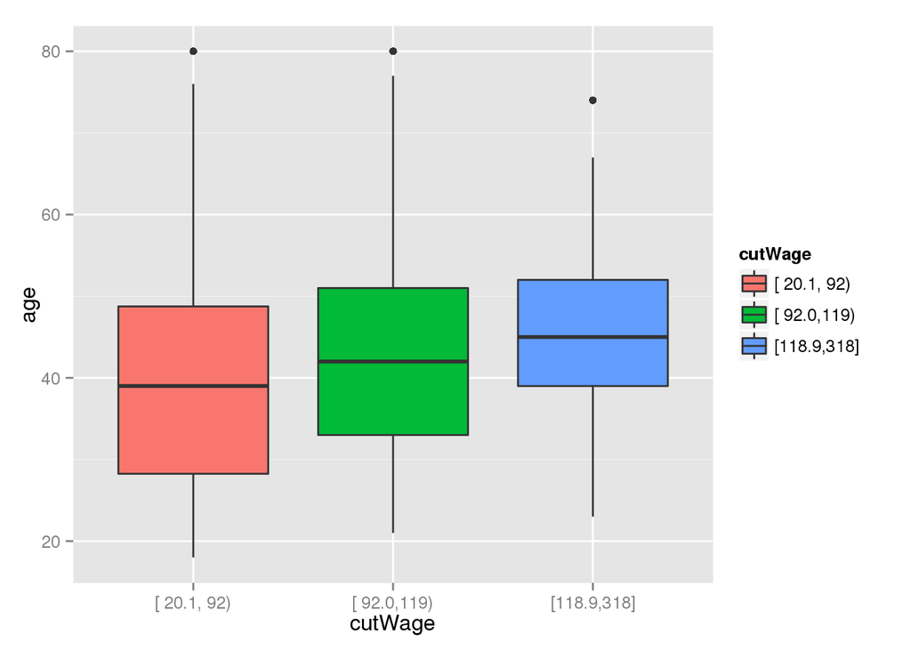

```r
# boxplots with cut2
p1 <- qplot(cutWage, age, data=training, fill=cutWage, geom=c("boxplot"))
p1
```

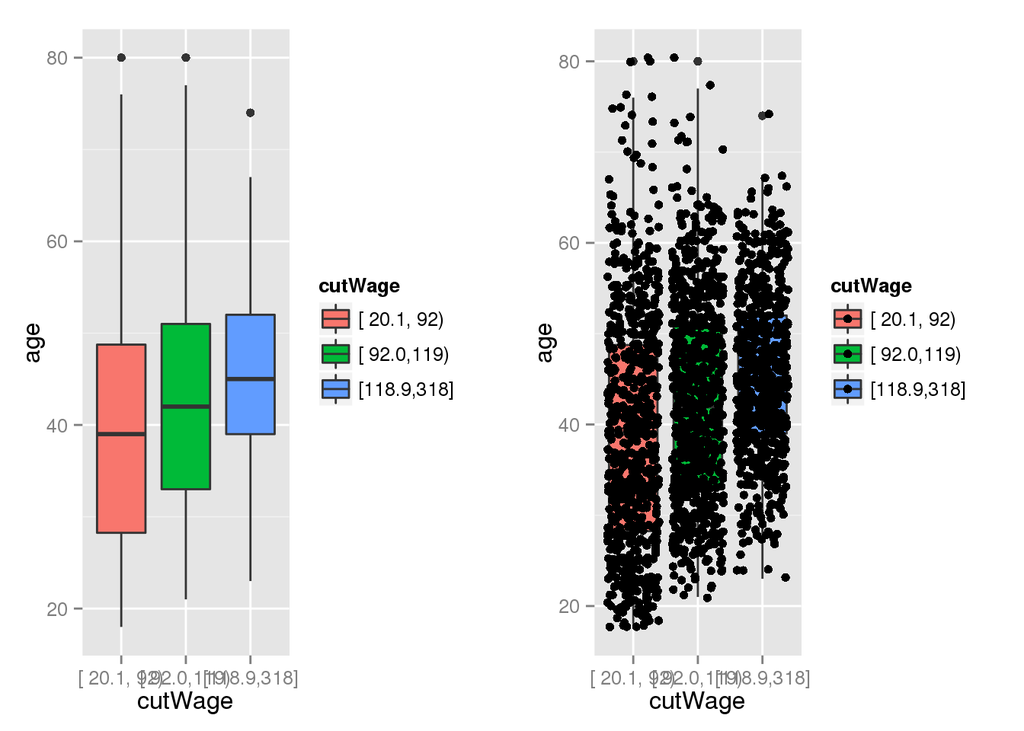

```r
# Boxplots with points overlayed
p2 <- qplot(cutWage, age, data=training, fill=cutWage, geom=c("boxplot", "jitter"))
library(gridExtra)
grid.arrange(p1,p2,ncol=2)
```

```r
# Tables
t1 <- table(cutWage, training$jobclass)
t1
```

```
##
## cutWage       1. Industrial 2. Information
##   [ 20.1, 92)           445            261
##   [ 92.0,119)           378            355
##   [118.9,318]           268            395
```

```r
prop.table(t1,1)
```

```
##
## cutWage       1. Industrial 2. Information
##   [ 20.1, 92)     0.6303116      0.3696884
##   [ 92.0,119)     0.5156889      0.4843111
##   [118.9,318]     0.4042232      0.5957768
```

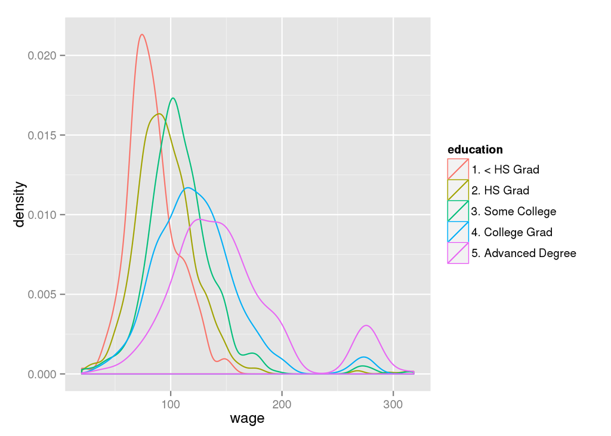

```r
# Density plots
qplot(wage, colour=education, data=training, geom="density")
```

## Why proprocess?

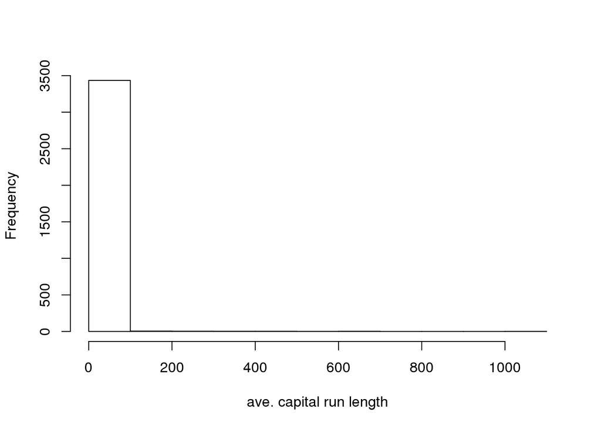

```r
library(caret); library(kernlab); data(spam)
inTrain <- createDataPartition(y = spam$type, p = 0.75, list=FALSE)
training <- spam[inTrain,]
testing <- spam[-inTrain,]
hist(training$capitalAve, main="", xlab="ave. capital run length")
```

very skewed

## Standardizing

```r
trainCapAve <- training$capitalAve
trainCapAveS <- (trainCapAve - mean(trainCapAve))/sd(trainCapAve)
mean(trainCapAveS)
```

```
## [1] -2.526009e-19
```

```r
sd(trainCapAveS)
```

```
## [1] 1
```

## Standardizing - test set

```r
testCapAve <- testing$capitalAve
testCapAveS <- (testCapAve - mean(trainCapAve))/sd(trainCapAveS)
mean(testCapAveS)
```

```
## [1] -0.2177296
```

## Standardizing - preProcessfunction

```r
preObj <- preProcess(training[, -58], method=c("center", "scale"))
trainCapAveS <- predict(preObj, testing[,-58])$capitalAve
mean(trainCapAveS)
```

```
## [1] -0.007056388
```

```r
sd(testCapAveS)
```

```
## [1] 34.23153
```

## Standardizing - preProcess argument

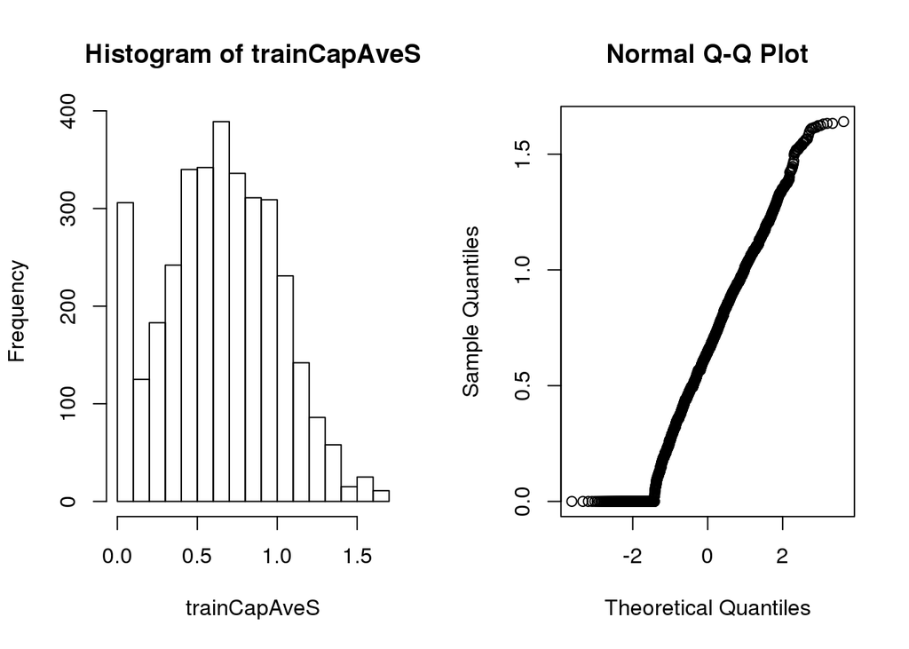

```r
preObj <- preProcess(training[, -58], method=c("BoxCox"))
trainCapAveS <- predict(preObj, training[,-58])$capitalAve
par(mfrow=c(1,2)); hist(trainCapAveS); qqnorm(trainCapAveS)
```

## Standardizing - Box-cox transforms

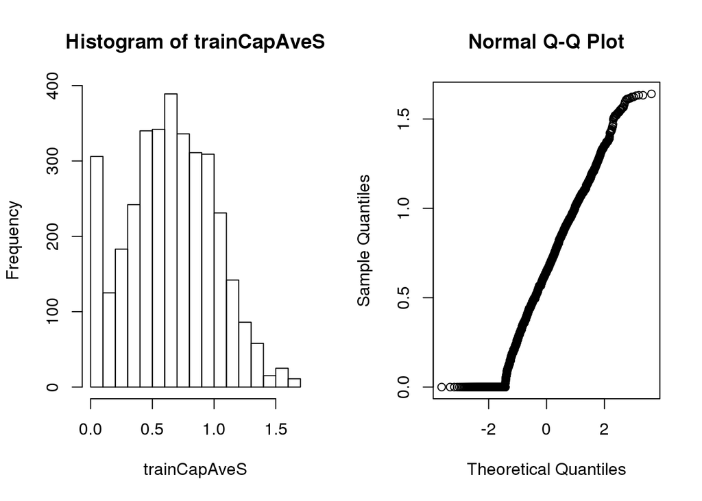

```r
preObj <- preProcess(training[,-58], method=c("BoxCox"))
trainCapAveS <- predict(preObj, training[,-58])$capitalAve
par(mfrow=c(1,2)); hist(trainCapAveS); qqnorm(trainCapAveS)
```

## Standardizing - Imputing data

```r
set.seed(13343)
#Make some values NA
training$capAve <- training$capitalAve
selectNA <- rbinom(dim(training)[1], size=1, prob=0.5)==1
training$capAve[selectNA] <- NA

# Impute and standardize
preObj <- preProcess(training[, -58], method="knnImpute")
capAve <- predict(preObj, training[,-58])$capAve


# Standardize true value
capAveTruth <- training$capitalAve
capAveTruth <- (capAveTruth - mean(capAveTruth))/sd(capAveTruth)

# Stardardizing - Imputing data
set.seed(13343)
# Make some values NA
training$capAve <- training$capitalAve
selectNA <- rbinom(dim(training)[1], size=1, prob=0.05)==1
training$capAve[selectNA] <- NA

# Impute and standardize
preObj <- preProcess(training[,-58], method = "knnImpute")
capAve <- predict(preObj, training[,-58])$capAve

# Standardize true values
capAveTruth <- training$capitalAve
capAveTruth <- (capAveTruth-mean(capAveTruth))/sd(capAveTruth)

# Standardizing - Imputing data
quantile(capAve - capAveTruth)
```

```
##            0%           25%           50%           75%          100%
## -11.944842570  -0.015751667  -0.009380329   0.003647631   6.010696343
```

```r
quantile((capAve-capAveTruth)[selectNA])
```

```
##            0%           25%           50%           75%          100%
## -11.944842570  -0.020882055  -0.001686707   0.013769048   1.296116467
```

```r
quantile((capAve - capAveTruth)[!selectNA])
```

```
##           0%          25%          50%          75%         100%
## -0.021018096 -0.015670157 -0.009466367  0.003292158  6.010696343
```

## Covariate

- Level1, Raw data -> covariates

summarization vs information loss

- Text files : Frequency of words, frequency of phrases (Google ngrams), frequency of capital letters.
- Images : Edges, corners, blobs, ridges (computer visin feature detection)
- Webpages : Number and type of images, position of elements, color, videos (A/B Testing)
- People : Height, weight, hair color, sex, country of origin.

```r
library(kernlab); data(spam)
spam$capitalAveSq <- spam$capitalAve^2
```

## Level2, Tidy covariates -> new covariates

- More necessary for some methods (regression, svms) than for otehrs(classification trees)
- Should be done only on the training set
- The best approach is through exploratory analysis(plotting/tables)
- New covariates should be added to data frames

## Load example data

```r
library(ISLR); library(caret); data(Wage);
inTrain <- createDataPartition(y=Wage$wage, p=0.7, list=FALSE)
training <- Wage[inTrain,]; testing <- Wage[-inTrain,]
```

## Common covariates to add , dummy variables

Basic idea - convert factor variables to indicator variables

```r
table(training$jobclass)
```

```
##
##  1. Industrial 2. Information
##           1051           1051
```

```r
dummies <- dummyVars(wage ~ jobclass, data=training)
head(predict(dummies, newdata=training))
```

```
##        jobclass.1. Industrial jobclass.2. Information
## 86582                       0                       1
## 161300                      1                       0
## 155159                      0                       1
## 11443                       0                       1
## 376662                      0                       1
## 450601                      1                       0
```

## Removing zero covariates

```r
nsv <- nearZeroVar(training, saveMetrics = TRUE)
nsv
```

```
##            freqRatio percentUnique zeroVar   nzv
## year        1.037356    0.33301618   FALSE FALSE
## age         1.027027    2.85442436   FALSE FALSE
## sex         0.000000    0.04757374    TRUE  TRUE
## maritl      3.272931    0.23786870   FALSE FALSE
## race        8.938776    0.19029496   FALSE FALSE
## education   1.389002    0.23786870   FALSE FALSE
## region      0.000000    0.04757374    TRUE  TRUE
## jobclass    1.000000    0.09514748   FALSE FALSE
## health      2.468647    0.09514748   FALSE FALSE
## health_ins  2.352472    0.09514748   FALSE FALSE
## logwage     1.061728   19.17221694   FALSE FALSE
## wage        1.061728   19.17221694   FALSE FALSE
```

## Spline basis

```r
library(splines)
bsBasis <- bs(training$age, df=3)
bsBasis
```

```
##                   1            2            3
##    [1,] 0.236850055 0.0253767916 9.063140e-04
##    [2,] 0.416337988 0.3211750193 8.258786e-02
##    [3,] 0.430813836 0.2910904300 6.556091e-02
##    [4,] 0.362525595 0.3866939680 1.374912e-01
##    [5,] 0.306334128 0.4241549461 1.957638e-01
##    [6,] 0.424154946 0.3063341278 7.374710e-02
##    [7,] 0.377630828 0.0906313987 7.250512e-03
##    [8,] 0.444358195 0.2275981001 3.885821e-02
##    [9,] 0.442218287 0.1953987782 2.877966e-02
##   [10,] 0.362525595 0.3866939680 1.374912e-01
##   [11,] 0.275519452 0.4362391326 2.302373e-01
##   [12,] 0.444093854 0.2114732637 3.356718e-02
##   [13,] 0.443086838 0.2436977611 4.467792e-02
##   [14,] 0.375000000 0.3750000000 1.250000e-01
```

[output cut: 2098 more lines]

## Fitting curves with splines

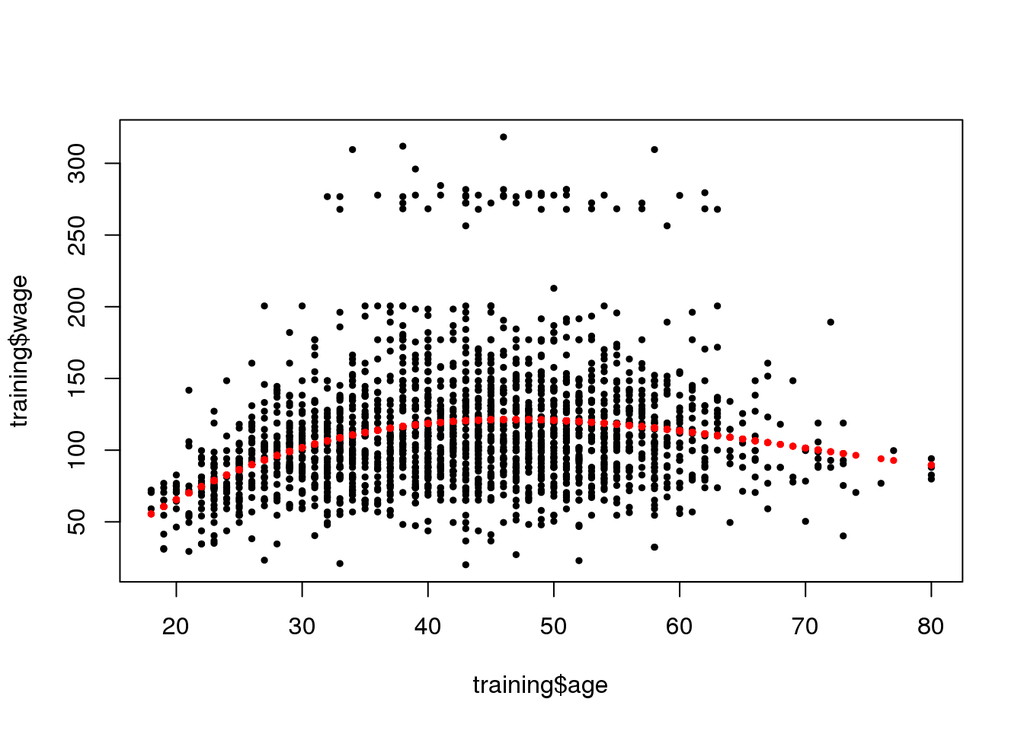

```r
lm1 <- lm(wage ~ bsBasis, data=training)
plot(training$age, training$wage, pch=19, cex=0.5)
points(training$age, predict(lm1, newdata=training), col="red", pch=19, cex=0.5)
```

## Splines on the test set

```r
predict(bsBasis, age=testing$age)
```

```
##                   1            2            3
##    [1,] 0.236850055 0.0253767916 9.063140e-04
##    [2,] 0.416337988 0.3211750193 8.258786e-02
##    [3,] 0.430813836 0.2910904300 6.556091e-02
##    [4,] 0.362525595 0.3866939680 1.374912e-01
##    [5,] 0.306334128 0.4241549461 1.957638e-01
##    [6,] 0.424154946 0.3063341278 7.374710e-02
##    [7,] 0.377630828 0.0906313987 7.250512e-03
##    [8,] 0.444358195 0.2275981001 3.885821e-02
##    [9,] 0.442218287 0.1953987782 2.877966e-02
##   [10,] 0.362525595 0.3866939680 1.374912e-01
##   [11,] 0.275519452 0.4362391326 2.302373e-01
##   [12,] 0.444093854 0.2114732637 3.356718e-02
##   [13,] 0.443086838 0.2436977611 4.467792e-02
##   [14,] 0.375000000 0.3750000000 1.250000e-01
```

[output cut: 2098 more lines]

## Notes and further reading

- Level 1 feature creation (raw data to covariates)
- Science is key. Google “feature extraction for [data type]”
- Err on overcreation of features
- In some applications (images, voices) automated feature creation is possible/necessary http://www.cs.nyu.edu/~yann/talks/lecun-ranzato-icml2013.pdf
- Level 2 feature creation (covariates to new covariates)
- The function preProcess in caret will handle some preprocessing.
- Create new covariates if you think they will improve fit
- Use exploratory analysis on the training set for creating them
- Be careful about overfitting!
- preprocessing with caret
- If you want to fit spline models, use the gam method in the caret package which allows smoothing of multiple variables.
- More on feature creation/data tidying in the Obtaining Data course from the Data Science course track.